# Lab 4: Visualizations

Now that we are comfortable working with arrays and Tables, we can visualize them (or subsets of them) to help us better understand the relationships between variables (e.g., correlation).

Please complete this lab by providing answers in cells after the question. Use **Code** cells to write and run any code you need to answer the question and **Markdown** cells to write out answers in words. After you are finished with the assignment, remember to download it as an **.html file** and submit it in **ELMS**.

```python
# load required packages
import numpy as np
from datascience import *

# These lines do some fancy plotting magic.
import matplotlib
%matplotlib inline
import matplotlib.pyplot as plt
```

## Reviewing Table Operations

Let's review some of the table operations we went over last week. We used methods such as `.group()` and `.pivot()` to get summaries of categorical variables. Let's take a look again at how it works using the `imdb` and `population` datasets.

```python
imdb = Table.read_table('imdb.csv')
imdb.show(5)
```

| Votes | Rating | Title | Year | Decade | Highly Rated |
| --- | --- | --- | --- | --- | --- |
| 88355 | 8.4 | M | 1931 | 1930 | False |
| 132823 | 8.3 | Singin' in the Rain | 1952 | 1950 | False |
| 74178 | 8.3 | All About Eve | 1950 | 1950 | False |
| 635139 | 8.6 | Léon | 1994 | 1990 | True |
| 145514 | 8.2 | The Elephant Man | 1980 | 1980 | False |

... (245 rows omitted)

```python
population_amounts = Table.read_table("world_population.csv")
years = np.arange(1950, 2016)
population = population_amounts.with_columns("Year", years)
population.show(5)
```

| Population | Year |
| --- | --- |
| 2557628654 | 1950 |
| 2594939877 | 1951 |
| 2636772306 | 1952 |
| 2682053389 | 1953 |
| 2730228104 | 1954 |

... (61 rows omitted)

### `.group()`

The table method `.group()` takes as its argument a string representing a column name. This gives the count of each category of that variable. **Remember to only use this with categorical variables, since it won't really make sense with numerical data.** Note that even if a variable has numbers, that doesn't mean it's a numerical variable. For example, we can find the number of movies that were released in each decade using `.group()` with the `Decade` variable.

```python
movies_by_decade = imdb.group('Decade')
movies_by_decade
```

| Decade | count |
| --- | --- |
| 1920 | 4 |
| 1930 | 7 |
| 1940 | 14 |
| 1950 | 30 |
| 1960 | 22 |
| 1970 | 21 |
| 1980 | 31 |
| 1990 | 42 |
| 2000 | 50 |
| 2010 | 29 |

We can also use the `collect` argument to summarize other variables split up by the categories in `Decade`.

```python
imdb.group('Decade', collect = np.mean)
```

| Decade | Votes mean | Rating mean | Title mean | Year mean | Highly Rated mean |
| --- | --- | --- | --- | --- | --- |
| 1920 | 64854 | 8.25 |  | 1924.75 | 0 |
| 1930 | 125825 | 8.27143 |  | 1935.57 | 0.285714 |
| 1940 | 122767 | 8.25714 |  | 1944.07 | 0.142857 |
| 1950 | 109829 | 8.23333 |  | 1955 | 0.133333 |
| 1960 | 147391 | 8.23182 |  | 1964.14 | 0.181818 |
| 1970 | 353377 | 8.30952 |  | 1975.62 | 0.285714 |
| 1980 | 295290 | 8.24194 |  | 1984.29 | 0.0967742 |
| 1990 | 559449 | 8.35714 |  | 1995.19 | 0.380952 |
| 2000 | 481929 | 8.26 |  | 2004.26 | 0.22 |
| 2010 | 438006 | 8.2 |  | 2012.31 | 0.172414 |

### `.pivot()`

You can use `.pivot()` to create contingency tables, looking at the counts for multiple categorical variables. You can also use `.pivot()` to find, for example, the mean of a third variable within each combination of categories. We'll focus on the first one for now. Let's say we want find out what the distribution of movies that got rated higher than 8.4 was by decade.

```python
imdb.pivot('Highly Rated','Decade')
```

| Decade | False | True |
| --- | --- | --- |
| 1920 | 4 | 0 |
| 1930 | 5 | 2 |
| 1940 | 12 | 2 |
| 1950 | 26 | 4 |
| 1960 | 18 | 4 |
| 1970 | 15 | 6 |
| 1980 | 28 | 3 |
| 1990 | 26 | 16 |
| 2000 | 39 | 11 |
| 2010 | 24 | 5 |

```python
imdb.pivot('Highly Rated','Decade', values = 'Rating', collect = np.mean)
```

| Decade | False | True |
| --- | --- | --- |
| 1920 | 8.25 | 0 |
| 1930 | 8.18 | 8.5 |
| 1940 | 8.20833 | 8.55 |
| 1950 | 8.16923 | 8.65 |
| 1960 | 8.14444 | 8.625 |
| 1970 | 8.12667 | 8.76667 |
| 1980 | 8.20714 | 8.56667 |
| 1990 | 8.15769 | 8.68125 |
| 2000 | 8.15641 | 8.62727 |
| 2010 | 8.125 | 8.56 |

**Question 1. Suppose we wanted to find the median rating of movies by decade. How might we do this?**

*Hint:* You might want to use `np.median()`.

```python
imdb.group('Decade', collect = np.median).select("Decade","Rating median")
```

| Decade | Rating median |
| --- | --- |
| 1920 | 8.25 |
| 1930 | 8.2 |
| 1940 | 8.3 |
| 1950 | 8.2 |
| 1960 | 8.2 |
| 1970 | 8.2 |
| 1980 | 8.2 |
| 1990 | 8.3 |
| 2000 | 8.2 |
| 2010 | 8.1 |

**Question 2. What if we wanted to figure out the distribution of highly rated movies among movies more than 50 years old. How might we do this?**

*Hint:* You can use an intermediate step and create a new Table.

```python
old_movies = imdb.where("Year", are.below(1975))
old_movies.group("Highly Rated")
```

| Highly Rated | count |
| --- | --- |
| False | 69 |
| True | 14 |

## Visualizations

Why did we spend so much time on manipulating data? Because to get the visualization that we want, we're going to need to use many of these tools. In this section, we'll use the `imdb` dataset to explore some basic descriptive statistics and data visualizations.

### Histograms and Boxplots

We can make histograms by using the `.hist()` method. To do this, though, you need to make sure that you only include the variable that you want as a Table. That is, you need to make sure that your data is in this form:

```python
imdb_rating = imdb.select('Rating')
imdb_rating.show(5)
```

| Rating |
| --- |
| 8.4 |
| 8.3 |
| 8.3 |
| 8.6 |
| 8.2 |

... (245 rows omitted)

We then use the `.hist()` method to create a histogram.

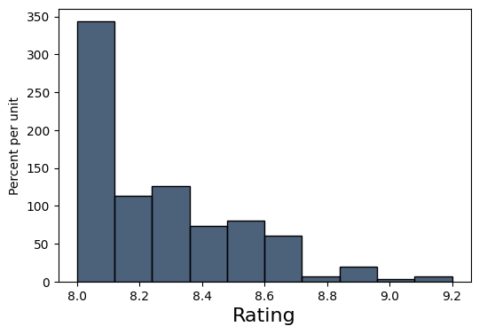

```python
imdb_rating.hist()
```

You can control characteristics about the histogram using parameters such as `bins`.

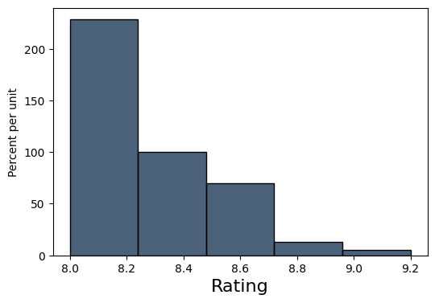

```python
imdb_rating.hist(bins = 5)
```

### Boxplots

Another visualization you can use for numerical data is a boxplot. As you might be able to guess, you can create this using the `.boxplot()` method. The data must be in a similar format.

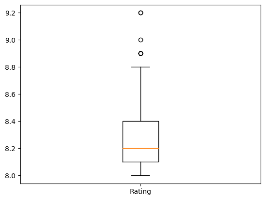

```python
imdb_rating.boxplot()
```

**Question 3. Make a histogram of the number of votes that movies got. What can you say about the shape and center of the distribution based on the histogram? Try using a few different bin values. Which one would be best to use?**

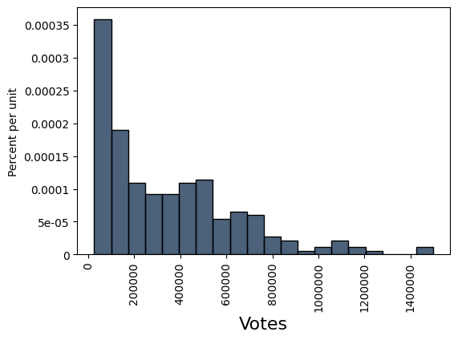

```python
imdb_votes = imdb.select("Votes")
imdb_votes.hist(bins = 20)
```

The shape of the distribution is skewed right. The best bin value to use is 20 because we can see more detail in the data and can see the outlier more clearly.

**Question 4. Make a boxplot of the number of votes that movies got. What can you say about the shape and center of the distribution?**

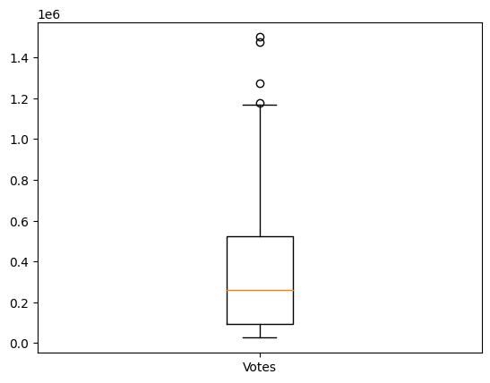

```python
imdb_votes_boxplot = imdb.select('Votes')
imdb_votes_boxplot.boxplot()
```

### Line Plot

Let's say we want to look at the change in movie ratings over time. To investigate this, we'll plot the mean rating over time.

First, we need to get the data in the form we want it. We want a column with the different decades in our dataset (the x-axis) as well as a column with the mean rating for that decade (the y-axis). To obtain a table with this data, we can use the `.group()` method, using `collect = np.mean` as an argument.

```python
rating_by_decade = imdb.select('Decade','Rating').group('Decade', collect = np.mean)
rating_by_decade
```

| Decade | Rating mean |
| --- | --- |
| 1920 | 8.25 |
| 1930 | 8.27143 |
| 1940 | 8.25714 |
| 1950 | 8.23333 |
| 1960 | 8.23182 |
| 1970 | 8.30952 |
| 1980 | 8.24194 |
| 1990 | 8.35714 |
| 2000 | 8.26 |
| 2010 | 8.2 |

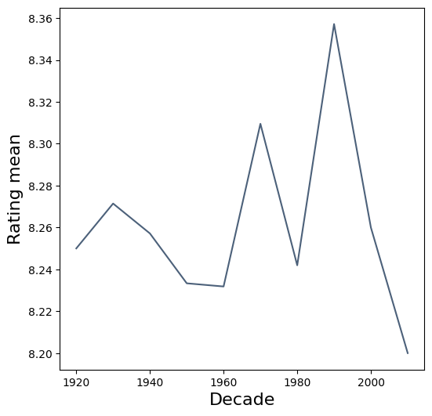

```python
# The variable to go on the x-axis is specified as the argument
rating_by_decade.plot('Decade')
```

**Question 5. Make a line plot of the mean number of votes by decade. Describe the trend.**

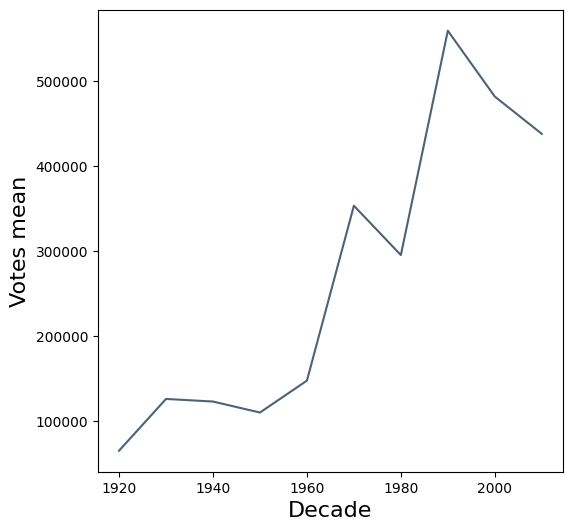

```python
mean_votes_decade = imdb.select('Decade','Votes').group('Decade', collect = np.mean)
mean_votes_decade.plot("Decade")

#The line graph has a positive trend
```

## Categorical Variables: Bar Chart

To make bar charts, we first need to create the summaries of the groups that we want to graph. Remember: bar charts are used for categorical variables. This means that we want to get the **counts** for each **category** in that variable. We can do this using the `.group()` method.

```python
movies_by_decade = imdb.group('Decade')
movies_by_decade.show(4)
```

| Decade | count |
| --- | --- |
| 1920 | 4 |
| 1930 | 7 |
| 1940 | 14 |
| 1950 | 30 |

... (6 rows omitted)

We take this table and use the `barh` method, specifying which variable we want to create the graph of.

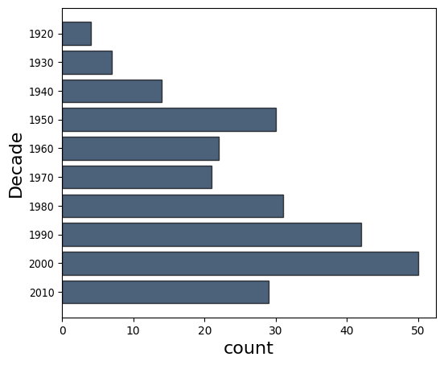

```python
movies_by_decade.barh('Decade')
```

To create a bar chart with multiple categories, we can use the `.pivot()` method to create a contingency table and use that instead of the `.group()` method.

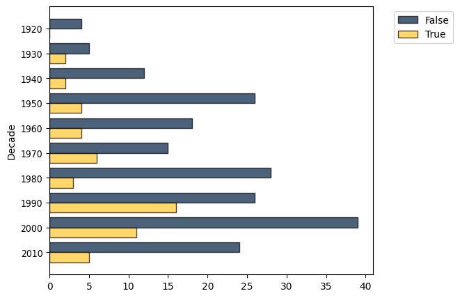

```python
imdb.pivot('Highly Rated','Decade').barh('Decade')
```

**Question 6. Create a bar graph with the counts of movies that were highly rated and not highly rated. Based on this graph and the graph of movies split by rating by decade, does any decade look particularly unusual to you?**

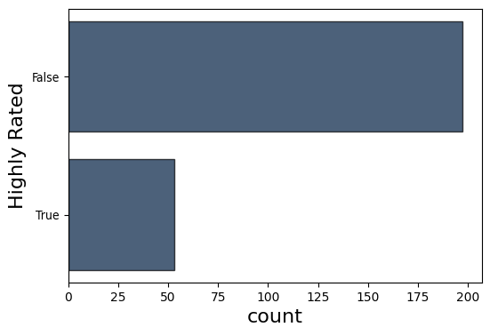

```python
imdb_high_low_rating = imdb.group('Highly Rated').barh('Highly Rated')
imdb_high_low_rating
```

The year 1990 looks closer to being ever with each other.

## Practice with Descriptive Statistics and Visualizations

For the last few questions, we will use the Cards Against Humanity Pulse of the Nation dataset to look at what characteristics might be associated with supporting federal funding of scientific research. Let's start by bringing in the dataset and taking a look at the variables.

```python
cah = Table.read_table('201709-CAH_PulseOfTheNation.csv')
```

```python
cah.show(5)
```

| Income | Gender | Age | Age Range | Political Affiliation | Level of Education | Race | Marital Status | Federal Funding of Scientific Research |
| --- | --- | --- | --- | --- | --- | --- | --- | --- |
| 68000 | Female | 56 | 55-64 | Democrat | High school | Black | Single | Too High |
| 46000 | Male | 63 | 55-64 | Independent | Some college | White | Married | About Right |
| 51000 | Male | 48 | 45-54 | Republican | High school | White | Divorced | About Right |
| 54000 | Female | 64 | 55-64 | Democrat | Some college | White | Married | Too Low |
| 83000 | Male | 61 | 55-64 | Independent | College degree | White | Divorced | About Right |

... (305 rows omitted)

The `Federal Funding of Scientific Research` column has answers to the question: "Is federal funding of scientific research too high, too low, or about right?" The `DK/REF` field refers to people who said they didn't know or refused to answer.

**Question 7. How many people who took this survey thought that federal funding of scientific research was too high? Too Low? About Right? Create a visualization that shows the distribution of answers to this question.**

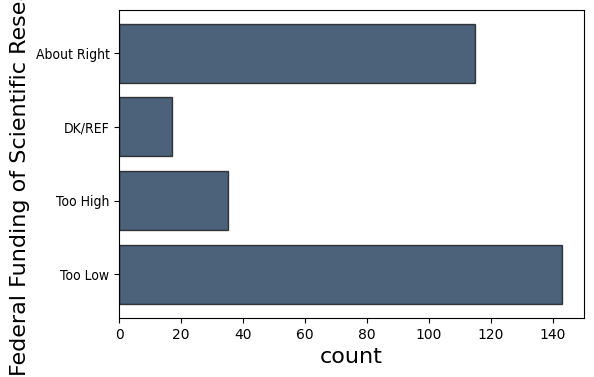

```python
fed_fund_opinions = cah.group('Federal Funding of Scientific Research')
fed_fund_opinions.barh('Federal Funding of Scientific Research')
```

**Question 8. Is level of education associated with opinions about federal funding of scientific research? Use descriptive statistics and visualizations to support your answer.**

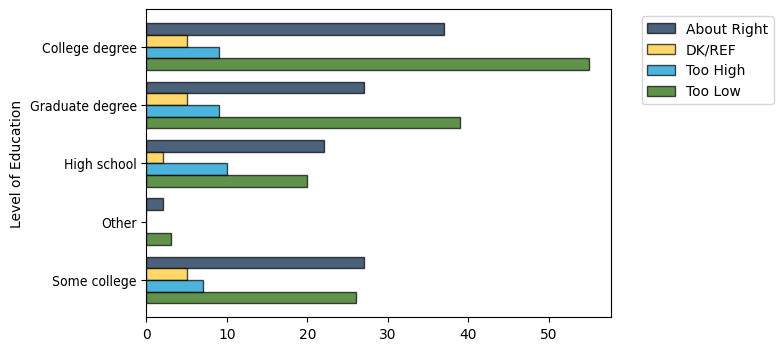

```python
stats_for_fed_fund = cah.stats()
fed_funding_edu = cah.pivot('Federal Funding of Scientific Research', 'Level of Education')
fed_funding_edu.barh('Level of Education')
```

The graph shows that people with a college education had the highest rate of thinking funding was too low through all categores.

**Question 9. Is income associated with opinions about federal funding of scientific research? Use descriptive statistics and visualizations to support your answer.**

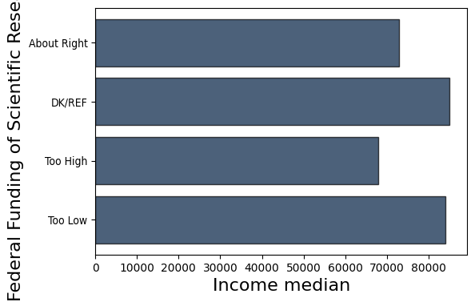

```python
fed_fund_income = cah.select('Income', 'Federal Funding of Scientific Research')
group_income = fed_fund_income.group('Federal Funding of Scientific Research', collect = np.median)
group_income.barh('Federal Funding of Scientific Research')
```

It's hard to tell if income is associated with opinions about federal funding but it looks like higher income has a realtion to having the opinion that funding is too low.

That's all for now. Please let us know if you have trouble understanding anything covered in this module, as we will only continue to build on this material in the coming weeks.